# Risk Factor Analysis

## Outcome Variable

**Outcome Variable:** whz

## Predictor Variables

**Intervention Variable:** fhtcm

**Adjustment Set:**

- arm
- W_mage
- W_fage
- meducyrs
- feducyrs
- W_mhtcm
- W_mwtkg
- W_mbmi
- single
- delta_W_mage
- delta_W_fage
- delta_meducyrs
- delta_feducyrs
- delta_W_mhtcm
- delta_W_mwtkg
- delta_W_mbmi
- delta_single

## Stratifying Variables

The analysis was stratified on these variable(s):

- agecat

## Data Summary

| agecat | fhtcm | n_cell | n |
| --- | --- | --- | --- |
| Birth | >=167 cm | 12466 | 13835 |
| Birth | <162 cm | 381 | 13835 |
| Birth | [162-167) cm | 988 | 13835 |
| 6 months | >=167 cm | 12638 | 14916 |
| 6 months | <162 cm | 808 | 14916 |
| 6 months | [162-167) cm | 1470 | 14916 |
| 24 months | >=167 cm | 4282 | 5439 |
| 24 months | <162 cm | 459 | 5439 |
| 24 months | [162-167) cm | 698 | 5439 |

The following strata were considered:

- agecat: 24 months
- agecat: 6 months
- agecat: Birth

## Methods Detail

We’re interested in the causal parameters $E[Y_a]$ for all values of $a \in \mathcal{A}$. These parameters represent the mean outcome if, possibly contrary to fact, we intervened to set all units to have $A=a$. Under the randomization and positivity assumptions, these are identified by the statistical parameters $\psi_a=E_W[E_{Y|A,W}(Y|A=a,W)]$. In addition, we’re interested in the mean of $Y$, $E[Y]$ under no intervention (the observed mean). We will estimate these parameters by using SuperLearner to fit the relevant likelihood factors – $E_{Y|A,W}(Y|A=a,W)$ and $p(A=a|W)$, and then updating our likelihood fit using a joint TMLE.

For unadjusted analyses ($W=\{\}$), initial likelihoods were estimated using Lrnr_glm to estimate the simple $E(Y|A)$ and Lrnr_mean to estimate $p(A)$. For adjusted analyses, a small library containing Lrnr_glmnet, Lrnr_xgboost, and Lrnr_mean was used.

Having estimated these parameters, we will then use the delta method to estimate relative risks and attributable risks relative to a prespecified baseline level of $A$.

# Results Detail

## Results Plots

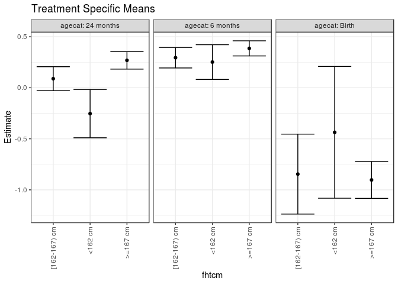

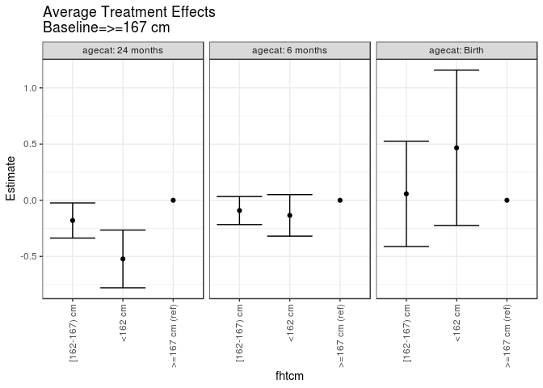

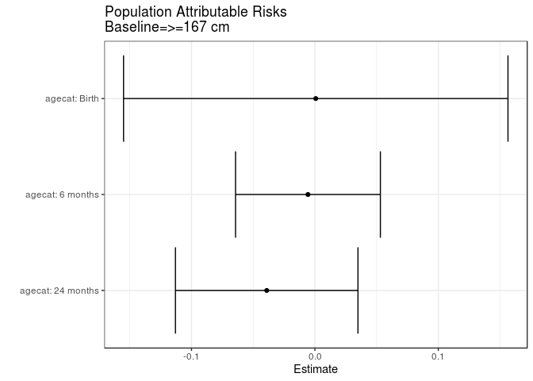

## Results Table

### Parameter: TSM

| agecat | intervention_level | baseline_level | estimate | ci_lower | ci_upper |
| --- | --- | --- | --- | --- | --- |
| Birth | >=167 cm | NA | -0.9029681 | -1.0838892 | -0.7220471 |
| Birth | <162 cm | NA | -0.4364032 | -1.0820191 | 0.2092127 |
| Birth | [162-167) cm | NA | -0.8457943 | -1.2374685 | -0.4541201 |
| 6 months | >=167 cm | NA | 0.3863874 | 0.3122153 | 0.4605594 |
| 6 months | <162 cm | NA | 0.2520357 | 0.0818431 | 0.4222284 |
| 6 months | [162-167) cm | NA | 0.2949351 | 0.1943241 | 0.3955462 |
| 24 months | >=167 cm | NA | 0.2690541 | 0.1831480 | 0.3549602 |
| 24 months | <162 cm | NA | -0.2529543 | -0.4898041 | -0.0161045 |
| 24 months | [162-167) cm | NA | 0.0891159 | -0.0284595 | 0.2066913 |

### Parameter: E(Y)

| agecat | intervention_level | baseline_level | estimate | ci_lower | ci_upper |
| --- | --- | --- | --- | --- | --- |
| Birth | NA | NA | -0.9022653 | -0.9990880 | -0.8054425 |
| 6 months | NA | NA | 0.3807690 | 0.3307544 | 0.4307835 |
| 24 months | NA | NA | 0.2300068 | 0.1846028 | 0.2754107 |

### Parameter: ATE

| agecat | intervention_level | baseline_level | estimate | ci_lower | ci_upper |
| --- | --- | --- | --- | --- | --- |
| Birth | >=167 cm | >=167 cm | 0.0000000 | 0.0000000 | 0.0000000 |
| Birth | <162 cm | >=167 cm | 0.4665649 | -0.2247485 | 1.1578784 |
| Birth | [162-167) cm | >=167 cm | 0.0571738 | -0.4113837 | 0.5257314 |
| 6 months | >=167 cm | >=167 cm | 0.0000000 | 0.0000000 | 0.0000000 |
| 6 months | <162 cm | >=167 cm | -0.1343517 | -0.3192382 | 0.0505349 |
| 6 months | [162-167) cm | >=167 cm | -0.0914522 | -0.2161181 | 0.0332136 |
| 24 months | >=167 cm | >=167 cm | 0.0000000 | 0.0000000 | 0.0000000 |
| 24 months | <162 cm | >=167 cm | -0.5220084 | -0.7786396 | -0.2653772 |
| 24 months | [162-167) cm | >=167 cm | -0.1799382 | -0.3361317 | -0.0237446 |

### Parameter: PAR

| agecat | intervention_level | baseline_level | estimate | ci_lower | ci_upper |
| --- | --- | --- | --- | --- | --- |
| Birth | >=167 cm | NA | 0.0007028 | -0.1550597 | 0.1564654 |
| 6 months | >=167 cm | NA | -0.0056184 | -0.0642996 | 0.0530628 |
| 24 months | >=167 cm | NA | -0.0390473 | -0.1130035 | 0.0349089 |